# Проект по SQL. База данных онлайн книг

**Описание проекта:** Коронавирус застал мир врасплох, изменив привычный порядок вещей. На какое-то время жители городов перестали выходить на улицу, посещать кафе и торговые центры. Зато стало больше времени для книг. Это заметили стартаперы — и бросились создавать приложения для тех, кто любит читать. Ваша компания решила быть на волне и купила крупный сервис для чтения книг по подписке. Ваша первая задача как аналитика — проанализировать базу данных.

**Цель исследования:** оценка ценностного предложения для сервиса для чтения книг по подписке.

#### Исследовательские задачи

- Посчитать, сколько книг вышло после 1 января 2000 года;
- Для каждой книги посчитать количество обзоров и среднюю оценку;
- Определить издательство, которое выпустило наибольшее число книг толще 50 страниц — так мы исключим из анализа брошюры;
- Определить автора с самой высокой средней оценкой книг — учитывать только книги с 50 и более оценками;
- Посчитать среднее количество обзоров от пользователей, которые поставили больше 48 оценок.

#### Описание данных

Таблица books cодержит данные о книгах:

- book_id — идентификатор книги;
- author_id — идентификатор автора;
- title — название книги;
- num_pages — количество страниц;
- publication_date — дата публикации книги;
- publisher_id — идентификатор издателя.

Таблица authors cодержит данные об авторах:

- author_id — идентификатор автора;
- author — имя автора.

Таблица publishers cодержит данные об издательствах:

- publisher_id — идентификатор издательства;
- publisher — название издательства;

Таблица ratings cодержит данные о пользовательских оценках книг:

- rating_id — идентификатор оценки;
- book_id — идентификатор книги;
- username — имя пользователя, оставившего оценку;
- rating — оценка книги.

Таблица reviews cодержит данные о пользовательских обзорах:

- review_id — идентификатор обзора;
- book_id — идентификатор книги;
- username — имя автора обзора;
- text — текст обзора.

```python
# импортируем библиотеки
import pandas as pd
from sqlalchemy import text, create_engine
import matplotlib.pyplot as plt
import seaborn as sns
```

```python
# применяем тему для графиков по умолчинию
# повысим качество изображения графиков
%config InlineBackend.figure_format='retina'
# Настройки графиков
sns.set_theme(style='whitegrid', palette='Set2', rc={'figure.figsize':(12, 6)})
```

```python
# устанавливаем параметры подключения
db_config = {'user': 'praktikum_student', # имя пользователя
'pwd': 'Sdf4$2;d-d30pp', # пароль
'host': 'rc1b-wcoijxj3yxfsf3fs.mdb.yandexcloud.net',
'port': 6432, # порт подключения
'db': 'data-analyst-final-project-db'} # название базы данных
connection_string = 'postgresql://{user}:{pwd}@{host}:{port}/{db}'.format(**db_config)
# сохраняем коннектор
engine = create_engine(connection_string, connect_args={'sslmode':'require'})
```

```python
# функция для создания запросов и вывода результата через таблицы pandas
def query(sql_query):
    return pd.io.sql.read_sql(sql=text(sql_query), con = engine.connect())
```

Исследуем таблицы: выведим первые строки.

```python
for table in ['books','authors', 'publishers', 'ratings', 'reviews']:
    print('\nТаблица "{}"'.format(table), end='')
    display(query(f'''SELECT * FROM {table} LIMIT 5'''))
    display(query(f'''SELECT COUNT(*) AS total_count FROM {table}'''))
```

```
Таблица "books"
```

|  | book_id | author_id | title | num_pages | publication_date | publisher_id |
| --- | --- | --- | --- | --- | --- | --- |
| 0 | 1 | 546 | 'Salem's Lot | 594 | 2005-11-01 | 93 |
| 1 | 2 | 465 | 1 000 Places to See Before You Die | 992 | 2003-05-22 | 336 |
| 2 | 3 | 407 | 13 Little Blue Envelopes (Little Blue Envelope... | 322 | 2010-12-21 | 135 |
| 3 | 4 | 82 | 1491: New Revelations of the Americas Before C... | 541 | 2006-10-10 | 309 |
| 4 | 5 | 125 | 1776 | 386 | 2006-07-04 | 268 |

|  | total_count |
| --- | --- |
| 0 | 1000 |

```
Таблица "authors"
```

|  | author_id | author |
| --- | --- | --- |
| 0 | 1 | A.S. Byatt |
| 1 | 2 | Aesop/Laura Harris/Laura Gibbs |
| 2 | 3 | Agatha Christie |
| 3 | 4 | Alan Brennert |
| 4 | 5 | Alan Moore/David Lloyd |

|  | total_count |
| --- | --- |
| 0 | 636 |

```
Таблица "publishers"
```

|  | publisher_id | publisher |
| --- | --- | --- |
| 0 | 1 | Ace |
| 1 | 2 | Ace Book |
| 2 | 3 | Ace Books |
| 3 | 4 | Ace Hardcover |
| 4 | 5 | Addison Wesley Publishing Company |

|  | total_count |
| --- | --- |
| 0 | 340 |

```
Таблица "ratings"
```

|  | rating_id | book_id | username | rating |
| --- | --- | --- | --- | --- |
| 0 | 1 | 1 | ryanfranco | 4 |
| 1 | 2 | 1 | grantpatricia | 2 |
| 2 | 3 | 1 | brandtandrea | 5 |
| 3 | 4 | 2 | lorichen | 3 |
| 4 | 5 | 2 | mariokeller | 2 |

|  | total_count |
| --- | --- |
| 0 | 6456 |

```
Таблица "reviews"
```

|  | review_id | book_id | username | text |
| --- | --- | --- | --- | --- |
| 0 | 1 | 1 | brandtandrea | Mention society tell send professor analysis. ... |
| 1 | 2 | 1 | ryanfranco | Foot glass pretty audience hit themselves. Amo... |
| 2 | 3 | 2 | lorichen | Listen treat keep worry. Miss husband tax but ... |
| 3 | 4 | 3 | johnsonamanda | Finally month interesting blue could nature cu... |
| 4 | 5 | 3 | scotttamara | Nation purpose heavy give wait song will. List... |

|  | total_count |
| --- | --- |
| 0 | 2793 |

Таблица "books" содержит 1000 записей, "authors" - 636, "publishers" - 340, "ratings" - 6456, "reviews" - 2793. Таблицы соответствуют обозначенной структуре.

Посчитаем, сколько книг вышло после 1 января 2000 года.

```python
query('''
SELECT COUNT(book_id) AS total_book_cnt
FROM books
WHERE publication_date >= '2000-01-01'
''')
```

|  | total_book_cnt |
| --- | --- |
| 0 | 821 |

Для каждой книги посчитаем количество обзоров и среднюю оценку.

```python
books_rating = query('''
WITH
book_ratings AS
(SELECT  book_id,
        ROUND(AVG(rating), 1) AS avg_rating
FROM ratings
GROUP BY book_id),

book_review_cnt AS
(SELECT  book_id,
        COUNT(review_id) AS review_cnt
FROM reviews
GROUP BY book_id)

SELECT  b.book_id,
        title,
        avg_rating,
        COALESCE(review_cnt, 0) AS review_cnt
FROM books AS b
LEFT OUTER JOIN book_ratings AS br ON b.book_id=br.book_id
LEFT OUTER JOIN book_review_cnt AS brc ON b.book_id=brc.book_id
ORDER BY avg_rating DESC
''')

with pd.option_context("display.max_rows", None, 'display.max_colwidth', None):
    display(books_rating)
```

|  | book_id | title | avg_rating | review_cnt |
| --- | --- | --- | --- | --- |
| 0 | 967 | Welcome to Temptation (Dempseys #1) | 5.0 | 2 |
| 1 | 347 | In the Hand of the Goddess (Song of the Lioness #2) | 5.0 | 2 |
| 2 | 321 | Homage to Catalonia | 5.0 | 2 |
| 3 | 224 | Evening Class | 5.0 | 2 |
| 4 | 17 | A Dirty Job (Grim Reaper #1) | 5.0 | 4 |
| 5 | 732 | The Ghost Map: The Story of London's Most Terrifying Epidemic—and How It Changed Science Cities and the Modern World | 5.0 | 2 |
| 6 | 20 | A Fistful of Charms (The Hollows #4) | 5.0 | 2 |
| 7 | 993 | Women | 5.0 | 2 |
| 8 | 516 | Plum Island (John Corey #1) | 5.0 | 2 |
| 9 | 57 | Act of Treason (Mitch Rapp #9) | 5.0 | 2 |
| 10 | 213 | Emily of New Moon (Emily #1) | 5.0 | 2 |
| 11 | 518 | Pop Goes the Weasel (Alex Cross #5) | 5.0 | 2 |
| 12 | 625 | The Adventures of Tom Sawyer and Adventures of Huckleberry Finn | 5.0 | 1 |
| 13 | 62 | Alas Babylon | 5.0 | 2 |
| 14 | 421 | Marvel 1602 | 5.0 | 2 |
| 15 | 169 | Crucial Conversations: Tools for Talking When Stakes Are High | 5.0 | 2 |
| 16 | 902 | The War of Art: Break Through the Blocks & Win Your Inner Creative Battles | 5.0 | 2 |
| 17 | 598 | Stolen (Women of the Otherworld #2) | 5.0 | 2 |
| 18 | 699 | The Demon-Haunted World: Science as a Candle in the Dark | 5.0 | 2 |
| 19 | 610 | Tai-Pan (Asian Saga #2) | 5.0 | 2 |
| 20 | 459 | My Name Is Asher Lev | 5.0 | 2 |
| 21 | 418 | March | 5.0 | 2 |
| 22 | 182 | Dead Souls | 5.0 | 2 |
| 23 | 136 | Captivating: Unveiling the Mystery of a Woman's Soul | 5.0 | 2 |
| 24 | 444 | Moneyball: The Art of Winning an Unfair Game | 5.0 | 3 |
| 25 | 275 | Geek Love | 5.0 | 2 |
| 26 | 390 | Light in August | 5.0 | 2 |
| 27 | 901 | The Walking Dead Book One (The Walking Dead #1-12) | 5.0 | 2 |
| 28 | 642 | The Big Bad Wolf (Alex Cross #9) | 5.0 | 2 |
| 29 | 229 | Evil Under the Sun (Hercule Poirot #24) | 5.0 | 2 |

[output cut: 970 more lines]

Количество строк в запросе 1000, поэтому построим гистограммы для общего представления по среднему рейтингу и количеству обзоров.

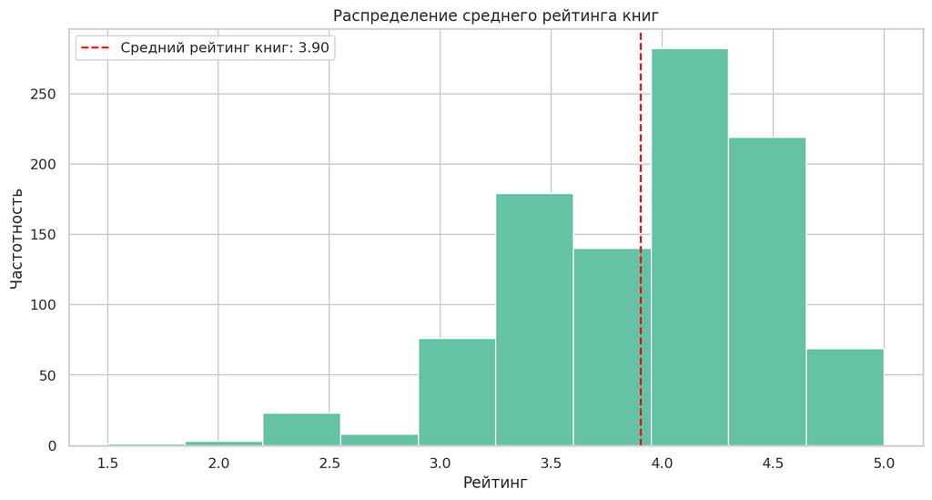

```python
books_rating.avg_rating.hist(bins=10);
plt.axvline(x=books_rating.avg_rating.mean(),
            color='red',
            linestyle='--',
            label='Средний рейтинг книг: {:.2f}'.format(books_rating.avg_rating.mean()))
plt.title('Распределение среднего рейтинга книг')
plt.xlabel('Рейтинг')
plt.ylabel('Частотность')
plt.legend()
plt.show()
```

Средний рейтинг книг в базе равен 3,9. Большинство книг имеет рейтинг выше 3.

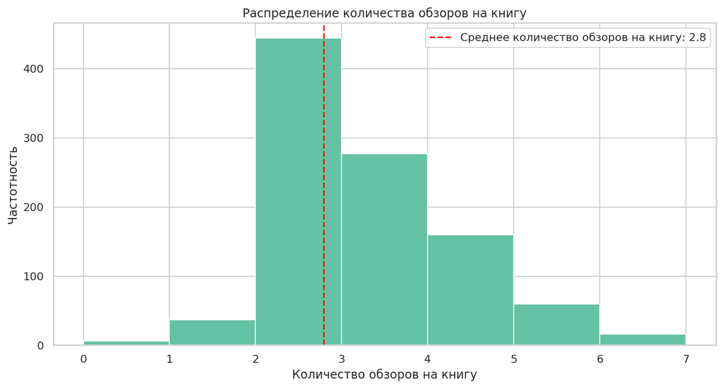

```python
books_rating.review_cnt.hist(bins=7);
plt.axvline(x=books_rating.review_cnt.mean(),
            color='red',
            linestyle='--',
            label='Среднее количество обзоров на книгу: {:.1f}'.format(books_rating.review_cnt.mean()))
plt.title('Распределение количества обзоров на книгу')
plt.xlabel('Количество обзоров на книгу')
plt.ylabel('Частотность')
plt.legend()
plt.show()
```

В среднем на книгу в базе приходится 2,8 обзора от читателей. Большинство книг получили от 2 до 4 обзоров.

Определим издательство, которое выпустило наибольшее число книг толще 50 страниц — так мы исключим из анализа брошюры.

```python
query('''
SELECT  publisher,
        COUNT(b.book_id) AS total_cnt
FROM books AS b
LEFT OUTER JOIN publishers AS p ON b.publisher_id=p.publisher_id
WHERE num_pages > 50
GROUP BY publisher
ORDER BY total_cnt DESC
LIMIT 5
''')
```

|  | publisher | total_cnt |
| --- | --- | --- |
| 0 | Penguin Books | 42 |
| 1 | Vintage | 31 |
| 2 | Grand Central Publishing | 25 |
| 3 | Penguin Classics | 24 |
| 4 | Bantam | 19 |

Определим автора с самой высокой средней оценкой книг — учтем только книги с 50 и более оценками.

```python
query('''
WITH
avg_book_ratings AS
(SELECT author_id,
        b.book_id,
        AVG(rating) AS avg_rating,
        COUNT(rating_id) AS rating_cnt
FROM ratings AS r
LEFT OUTER JOIN books AS b ON b.book_id=r.book_id
GROUP BY author_id, b.book_id
HAVING COUNT(rating_id) >= 50
ORDER BY avg_rating DESC),

avg_author_rating AS
(SELECT  author_id,
        AVG(avg_rating) AS avg_author_rating
FROM avg_book_ratings
GROUP BY author_id
ORDER BY avg_author_rating DESC)

SELECT  author,
        ROUND(avg_author_rating, 2) AS avg_rating
FROM authors as a
RIGHT OUTER JOIN avg_author_rating AS aar ON aar.author_id=a.author_id
ORDER BY avg_author_rating DESC
LIMIT 5
''')
```

|  | author | avg_rating |
| --- | --- | --- |
| 0 | J.K. Rowling/Mary GrandPré | 4.28 |
| 1 | Markus Zusak/Cao Xuân Việt Khương | 4.26 |
| 2 | J.R.R. Tolkien | 4.26 |
| 3 | Louisa May Alcott | 4.19 |
| 4 | Rick Riordan | 4.08 |

Посчитаем среднее количество обзоров от пользователей, которые поставили больше 48 оценок.

```python
query('''
WITH
user_review_cnt AS
(SELECT username,
       COUNT(review_id) AS review_cnt
FROM reviews
WHERE username IN (SELECT username
                    FROM ratings
                    GROUP BY username
                    HAVING COUNT(rating_id) > 48)
GROUP BY username)

SELECT ROUND(AVG(review_cnt), 2) AS avg_review_cnt
FROM user_review_cnt

''')
```

|  | avg_review_cnt |
| --- | --- |
| 0 | 24.0 |

## Выводы по исследованию базы книг

- Всего книг в базе данных 1000 шт от 636 авторов.
- В базе 821 книга, которая была опубликована в XXI веке.
- Средний рейтинг книг в базе равен 3,9. Большинство книг имеет рейтинг выше 3.
- В среднем на книгу в базе приходится 2,8 обзора от читателей. Большинство книг получили от 2 до 4 обзоров.
- От издательтсва "Penguin Books" представлено больше всего книг - 42 штуки.
- Автор с самой высокой средней оценкой книг является J.K. Rowling/Mary GrandPré - 4,28.
- Среднее количество обзоров от пользователей, которые поставили больше 48 оценок, равно 24.

## Рекомендации

На основе предоставленных данных можно сформулировать следующие ценностные предложения для сервиса чтения книг по подписке:

1. **Широкий выбор современных книг**: подчеркните, что в базе данных представлено более 800 книг, опубликованных в XXI веке, что может привлечь читателей, интересующихся актуальными произведениями и тенденциями в литературе.
2. **Высокое качество контента**: средний рейтинг книг в базе данных составляет 3,9, что свидетельствует о высоком качестве предлагаемых произведений. Это может стать аргументом для привлечения читателей, ищущих интересные и хорошо оценённые книги.
3. **Отзывы и рекомендации от других читателей**: среднее количество обзоров на книгу составляет 2,8, что говорит о наличии активного сообщества читателей, готовых делиться своими впечатлениями и рекомендациями. Это может помочь новым пользователям выбрать интересные книги.
4. **Разнообразие авторов и издательств**: в базе данных представлено более 600 авторов, включая таких известных, как J.K. Rowling, чьи книги имеют высокий средний рейтинг. Также можно отметить присутствие крупного издательства «Penguin Books», что может добавить доверия к сервису.
5. **Возможность познакомиться с популярными авторами**: упоминание о высоком среднем рейтинге книг определённого автора (например, J.K. Rowling) может привлечь поклонников её творчества и тех, кто хочет познакомиться с её произведениями.
6. **Активное сообщество читателей**: среднее количество обзоров от активных пользователей (более 48 оценок) составляет 24, что указывает на наличие активного и вовлечённого сообщества. Это может создать ощущение принадлежности к сообществу любителей чтения и стимулировать пользователей к подписке.